# PrimerMiner: an r package for development and in silico validation of DNA metabarcoding primers - Elbrecht - 2017 - Methods in Ecology and Evolution - Wiley Online Library

[Methods in Ecology and Evolution](https://besjournals.onlinelibrary.wiley.com/journal/2041210x)

[Volume 8, Issue 5](https://besjournals.onlinelibrary.wiley.com/toc/2041210x/2017/8/5) p. 622-626

[figure not shown]

Application

Free Access

# PrimerMiner: an r package for development and *in silico* validation of DNA metabarcoding primers

[Vasco Elbrecht](https://besjournals.onlinelibrary.wiley.com/authored-by/ContribAuthorRaw/Elbrecht/Vasco),

[Florian Leese](https://besjournals.onlinelibrary.wiley.com/authored-by/ContribAuthorRaw/Leese/Florian),

First published: 18 October 2016

https://doi.org/10.1111/2041-210X.12687

## Summary

1. DNA metabarcoding is a powerful tool to assess biodiversity by amplifying and sequencing a standardized gene marker region. Its success is often limited due to variable binding sites that introduce amplification biases. Thus, the development of optimized primers for communities or taxa under study in a certain geographic region and/or ecosystems is of critical importance. However, no tool for obtaining and processing of reference sequence data in bulk that can serve as a backbone for primer design is currently available.
2. We developed the r package PrimerMiner, which batch downloads DNA barcode gene sequences from BOLD and NCBI data bases for specified target taxonomic groups and then applies sequence clustering into operational taxonomic units (OTUs) to reduce biases introduced by the different number of available sequences per species. Additionally, PrimerMiner offers functionalities to evaluate primers *in silico*, which are in our opinion more realistic than the strategy employed in another available software for that purpose, ecoPCR.
3. We used PrimerMiner to download cytochrome *c* oxidase subunit I (COI) sequences for 15 important freshwater invertebrate groups, relevant for ecosystem assessment. By processing COI markers from both data bases, we were able to increase the amount of reference data 249-fold on average, compared to using complete mitochondrial genomes alone. Furthermore, we visualized the generated OTU sequence alignments and describe how to evaluate primers *in silico* using PrimerMiner.
4. With PrimerMiner, we provide a useful tool to obtain relevant sequence data for targeted primer development and evaluation. The OTU-based reference alignments generated with PrimerMiner can be used for manual primer design or processed with bioinformatic tools for primer development.

## Introduction

Metabarcoding allows rapid DNA-based species identification from environmental samples often containing hundreds or thousands of specimens. DNA is extracted in bulk, a barcoding marker amplified and sequenced with high-throughput sequencing followed by bioinformatic processing (Taberlet *et al*. 2012). However, typically used marker regions like the cytochrome *c* oxidase subunit I (COI) fragment for animals often show highly variable primer binding sites (Deagle *et al*. 2014; Sharma & Kobayashi 2014) leading sometimes to substantial primer bias and species remaining undetected (Piñol *et al*. 2014; Elbrecht & Leese 2015). Therefore, we argue that for optimal performance metabarcoding primers should be optimized to the specific taxonomic groups of interest in the geographic region/ecosystem under study. Many primers used in metabarcoding studies, however, are often not thoroughly evaluated or were developed on a limited reference data set or mitochondrial genomes (Geller *et al*. 2013; Deagle *et al*. 2014; Brandon-Mong *et al*. 2015) or large but often not order/family specific data sets of partial marker sequences (Zeale *et al*. 2010; Leray *et al*. 2013; Gibson *et al*. 2014). However, downloading all relevant reference data from the respective data bases can also introduce biases. A key problem is that certain taxa are often overrepresented with hundreds of sequences, for example from sequences available from phylogeographic studies. This artificial inflation for specific taxa can in principle be circumvented when using only mitochondrial genomes. Yet, such data sets are often very limited because mitochondrial genomic sequences are still rare for many taxonomic groups. However, obtaining good-quality reference data is essential for primer development and evaluation. An additional problem when developing primers is that available *in silico* primer evaluation tools such as ecoPCR v1.01 (Ficetola *et al*. 2010) are based on in our opinion oversimplified models, which do not take into account the position and type of mismatches. However, as mismatches at or near the 3′ end of the primer have a much greater effect on PCR success than other mismatches (Stadhouders *et al*. 2010; Piñol *et al*. 2014), it is important to focus specifically on these. To address these concerns in DNA metabarcoding primer development, we have developed the r package PrimerMiner, which allows for batch downloading and processing of sequences for specified groups. The software also has additional alignment visualization and novel *in silico* primer evaluation capabilities.

## Package description

### PrimerMiner: a batch sequence downloader

PrimerMiner is an r-based package that batch downloads sequences data from NCBI and BOLD and clusters them into operational taxonomic units (OTUs) using Vsearch (Fig. 1, Rognes *et al*. 2016). Sequence data for a chosen genetic marker are downloaded for each specified taxonomic group. Target sequences are also extracted from mitochondrial genomes if available. Thus, PrimerMiner takes full advantage of available partial sequences and mitochondrial genomes, laying a good data basis for primer development. All sequences are then clustered into OTUs using a 3% sequence similarity by default. OTU consensus sequences are saved in a fasta file for each taxonomic group and can then be aligned and used for manual or software-based primer design. This clustering strategy utilized in PrimerMiner has several key advantages:

1. Overrepresented taxa and duplicated sequences are merged into a few OTUs.
2. Taxonomic variation within a species can be retained (wobble bases), while rare haplotypes are ignored in the OTU consensus sequences.
3. Highly diverse (potentially cryptic) species are automatically represented by two or more OTUs.
4. Clustering is taxonomy-independent and thus can deal with misidentified species as long as their order or family was identified correctly.

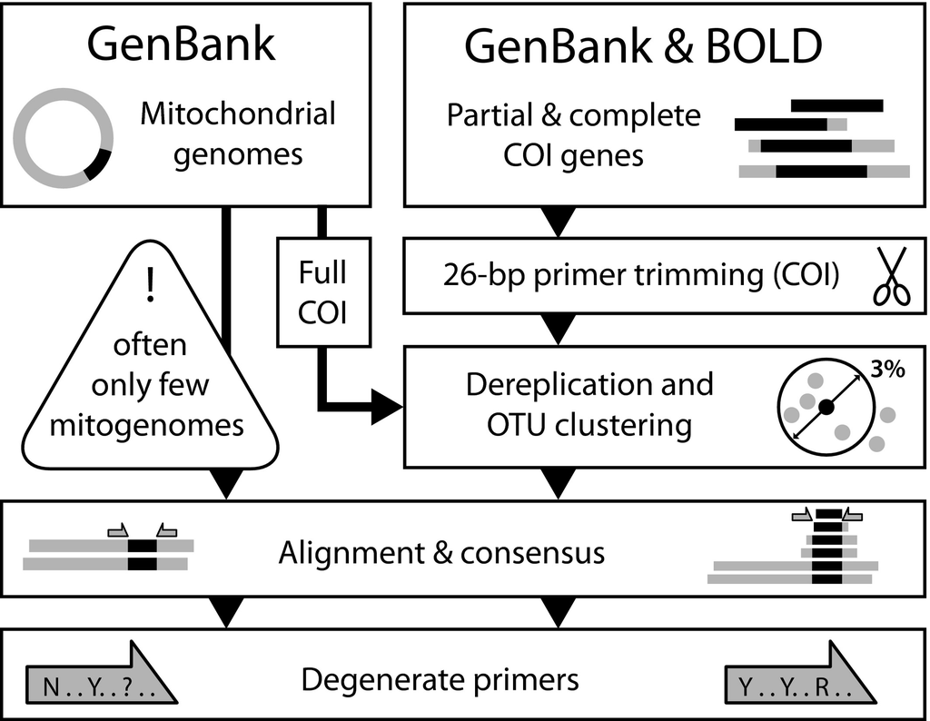

**Figure 1**

Overview of the principle behind the PrimerMiner package for sequence downloading and clustering. Both mitochondrial genomes and partial gene sequences are downloaded and clustered to make maximum use of the available sequence information while minimizing biases introduced by overrepresented taxa in the sequence data. Primer trimming is necessary if primers have not been removed from all sequences in the data base.

For batch downloading sequence data, PrimerMiner needs two files, one configuration file that can be generated by running batch_config(“config.txt”) in r and a taxonomy table specifying the groups for which data should be downloaded (csv table, see Appendix S1, Supporting Information). The default options in the configuration file are optimized for the COI barcoding marker, but other marker genes can be downloaded as well (e.g. Marker = “16S”). At this point, only COI markers are downloaded from BOLD and marker extraction is limited to mitochondrial genomes but support for additional markers and chloroplast genomes is planned. By default, the majority consensus sequence for each OTU is saved for each group, but OTU diversity can be captured by including wobble bases in the consensus sequences (e.g. threshold = 0·1). PrimerMiner is optimized to download data on order level (fist table column, Appendix S1) with the option to specify a subset of taxa on family level in the second column if, for example, only aquatic Coleoptera (beetle) families should be targeted. Downloading data for taxonomic groups below family level rank (genus or species level) can cause problems, if identical taxonomic names are used across several groups. By running batch_download(“taxa_table.csv”, “config.txt”) target barcode sequences are downloaded and processed. This can take a few hours depending on data set size, but PrimerMiner will keep you updated and report once it has finished in the r console.

To visualize the downloaded sequence data, OTUs from each group have to be aligned and trimmed to the target marker region. We deliberately did not automate this process as part of the PrimerMiner strategy, as we highly recommend to visually inspect the alignments and remove misaligned sequences and gaps. Different markers or groups typically need specific attention because data bases can contain errors or alignment parameters need to be adjusted; thus, we refrain from automating this step at this moment. OTUs can be aligned with tools like mafft (Katoh *et al*. 2002) as implemented in Geneious (Kearse *et al*. 2012) and gaps in the alignment can be removed using the ‘Strip Alignment Columns’ feature in Geneious. We generally suggest ~100 OTUs for each order as a minimum coverage to capture its variability of primer binding sites and select necessary wobble bases. Once the alignments are generated and exported as fasta files, they can be visualized using the plot_alignments(c(“file1.fasta”, “file2.fasta”)) function in PrimerMiner to manually search for new and evaluate existing primers (Fig. 2). These alignments can then also be used to develop primers with automated tools such as Primer3 (Untergasser *et al*. 2012) or ecoPCR (Ficetola *et al*. 2010).

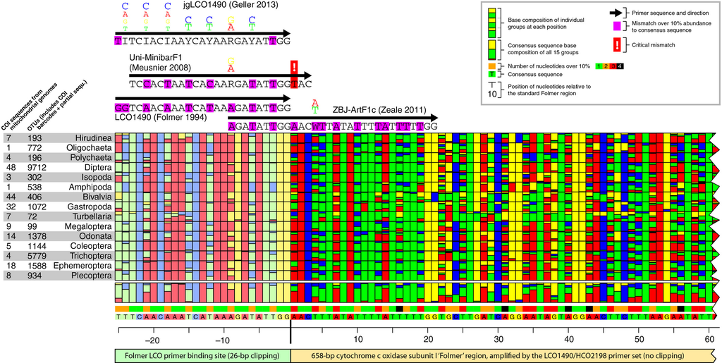

**Figure 2**

To test the PrimerMiner package, we have downloaded and processed COI sequence data for 15 important freshwater macroinvertebrate groups. The alignments visualized in Fig. 2 are available as fasta files on Dryad (doi:10.5061/dryad.4c3g9). Compared to using mitochondrial genomes alone sequence coverage of the 15 groups was increased 249-fold (SD = 395) on average by including COI OTU sequences generated with PrimerMiner (number of OTUs for each group divided by available mitochondrial genomes). Additionally, in Fig. 2 we have added a few commonly used barcoding and metabarcoding primers binding in the Folmer LCO primer binding site (Folmer *et al*. 1994). Some of these primers show a high number of mismatches due to the lack of degeneracy (LCO1490, Folmer *et al*. 1994; ZBJ-ArtF1c, Zeale *et al*. 2010), and in the case of the Uni-MinibarF1 primer even strong mismatches on the 3′ end of the primer (Meusnier *et al*. 2008). These problematic primers likely introduce biases in metabarcoding studies (Piñol *et al*. 2014; Elbrecht & Leese 2015) illustrating how critical careful primer evaluation is not only when designing novel primers but also when choosing primers from the literature.

### *In silico* primer evaluation

PrimerMiner also introduces powerful *in silico* primer evaluation capabilities, allowing the evaluation of single primers and primer pairs on any given sequence alignment. Unlike ecoPCR (Ficetola *et al*. 2010), PrimerMiner factors in the adjacency, position and type of each mismatch between primer and template sequence. This is important because amplification success depends highly on good matches at the 3′ end of the primer (Stadhouders *et al*. 2010; Piñol *et al*. 2014). Using the command evaluate_primer(“Alignment.fasta”, “Primersequence”, bind_start, bind_stop, save= “filename.csv”, mm_position = “Position_v1.csv”, adjacent=2, mm_type = “Type_v1.csv”) PrimerMiner calculates an individual penalty score for each template to primer mismatch and reports these in a table format, which can then be further analysed.

PrimerMiner evaluates these parameters in the following order:

1. Scoring of mismatches based on position (based on the provided table in mm_position).
2. Score adjustment based on mismatch types (based on the provided table in mm_type).
3. Increasing of penalties for two adjacent mismatches (by default penalty scores are duplicated adjacent=2).
4. Reduction of penalty scores if wobble bases are present in the target sequence, which partially match the primer.

Penalty scores for position and mismatch type are fully customizable by providing own penalty tables. Example mismatch type and mismatch position scoring tables are included in the example data of the PrimerMiner package. Two penalty score tables can be evaluated with primer_threshold(“table 1.csv”, “table 2.csv”, threshold=100) using a defined threshold under which a primer pair is considered not amplifying. As detailed penalty scores are provided for each sequence and primer combination, more elaborate statistical analysis is easily possible.

### Package availability, documentation and sample data

The PrimerMiner package and example sequence alignments (Fig. 2) are available on github (https://github.com/VascoElbrecht/PrimerMiner), alongside extensive documentation in the GitHub wiki including YouTube video tutorials. After downloading the package, it can be installed with install.packages(“path_to_file”, repos = NULL, type=“source”, dependencies=T) in r. As the PrimerMiner is bundled with the Vsearch v1.10.2 binary, it cannot be made available on CRAN. At this time, a windows version is not available, because for windows only Usearch v8.1.1861 is available, which in contrast to Vsearch produces poor-quality alignments of OTU sequences (Edgar 2013).

## Conclusions

We here described the first release of the package PrimerMiner, a useful tool to obtain reference sequence data for targeted primer development and evaluation using its alignment visualization capabilities as well as refined *in silico* evaluation functions. A thorough *in silico* and *in vivo* evaluation of existing primers is needed, as many primers might not be suitable for DNA metabarcoding due to low base degeneracy, potentially high primer bias or critical design flaws. Additionally, developing primers specific to ecosystems, geographic areas and taxonomic groups of interest is encouraged to maximize performance.

## Authors’ contributions

V.E. and F.L. conceived the ideas and designed methodology; V.E. collected and analysed the data; V.E. programmed the r package; V.E. led the writing of the manuscript. All authors contributed critically to the drafts and gave final approval for publication.

## Acknowledgements

F.L. and V.E. are supported by a grant of the Kurt Eberhard Bode foundation to F.L. We thank Jan Macher and Edith Vamos for proofreading and two anonymous reviewers for their comments which improved this manuscript. The authors report no conflict of interests.

## Data accessibility

Full sequence alignments of the 15 freshwater groups visualized in Fig. 2 are available on Dryad Digital Repository http://dx.doi.org/10.5061/dryad.4c3g9 (Elbrecht & Leese 2016).

## Citing Literature

[figure not shown]

[Volume8, Issue5](https://besjournals.onlinelibrary.wiley.com/toc/2041210x/2017/8/5)

May 2017

Pages 622-626